# Heart Disease Prediction

```r
rm(list=ls())
```

# Introduzione

La presente analisi ha come obiettivo quello di individuare i fattori che concorrono ad aumentare il rischio di contrarre nel futuro malattie cardiovascolari, nonché quello di individuare un classificatore che meglio riesca a prevedere tale rischio. Una prognosi tempestiva, infatti, può essere utile nel prendere decisioni riguardo al cambio di stile divita dei pazienti ad alto rischio e ridurre il rischio di complicazioni.

# Library Imports

```r
library(skimr)
library(dplyr)
library(caret)
library(corrplot)
library(ROCR)
library(MASS)
library(psych)
library(ggplot2)
library(klaR)
library(tidyr)
library(cowplot)
library(mlbench)
library(AppliedPredictiveModeling)
library(car)
library(rattle)
library(e1071)
library(kernlab)
library(ROSE)
```

# Data Set Import

Il Data Set utilizzato riguarda uno studio condotto sulla popolazione della città di Framingham, Massachusetts. I classificatori proposti avranno l’obiettivo di individuare tutti quei pazienti considerati a rischio, ovvero quelli che potrebbero contrarre una malattia cardiovascolare entro 10 anni (`TenYearCHD`). Per fare ciò si utilizzeranno circa 4000 osservazioni e 15 variabili indipendenti.

```r
df = read.csv("framingham.csv", header = T)

attach(df)
head(df)
```

```
##   male age education currentSmoker cigsPerDay BPMeds prevalentStroke
## 1    1  39         4             0          0      0               0
## 2    0  46         2             0          0      0               0
## 3    1  48         1             1         20      0               0
## 4    0  61         3             1         30      0               0
## 5    0  46         3             1         23      0               0
## 6    0  43         2             0          0      0               0
##   prevalentHyp diabetes totChol sysBP diaBP   BMI heartRate glucose TenYearCHD
## 1            0        0     195 106.0    70 26.97        80      77          0
## 2            0        0     250 121.0    81 28.73        95      76          0
## 3            0        0     245 127.5    80 25.34        75      70          0
## 4            1        0     225 150.0    95 28.58        65     103          1
## 5            0        0     285 130.0    84 23.10        85      85          0
## 6            1        0     228 180.0   110 30.30        77      99          0
```

Nella sezione successiva andremo ad analizzare nel dettaglio il Data Set in questione e al contempo svolgeremo le operazioni di Pre-processing necessarie alla nostra analisi.

# EDA & Pre-Processing

Tramite la funzione `str()` possiamo osservare che il Data Set contiene 4238 osservazioni e 16 variabili.

```r
str(df)
```

```
## 'data.frame':    4238 obs. of  16 variables:
##  $ male           : int  1 0 1 0 0 0 0 0 1 1 ...
##  $ age            : int  39 46 48 61 46 43 63 45 52 43 ...
##  $ education      : int  4 2 1 3 3 2 1 2 1 1 ...
##  $ currentSmoker  : int  0 0 1 1 1 0 0 1 0 1 ...
##  $ cigsPerDay     : int  0 0 20 30 23 0 0 20 0 30 ...
##  $ BPMeds         : int  0 0 0 0 0 0 0 0 0 0 ...
##  $ prevalentStroke: int  0 0 0 0 0 0 0 0 0 0 ...
##  $ prevalentHyp   : int  0 0 0 1 0 1 0 0 1 1 ...
##  $ diabetes       : int  0 0 0 0 0 0 0 0 0 0 ...
##  $ totChol        : int  195 250 245 225 285 228 205 313 260 225 ...
##  $ sysBP          : num  106 121 128 150 130 ...
##  $ diaBP          : num  70 81 80 95 84 110 71 71 89 107 ...
##  $ BMI            : num  27 28.7 25.3 28.6 23.1 ...
##  $ heartRate      : int  80 95 75 65 85 77 60 79 76 93 ...
##  $ glucose        : int  77 76 70 103 85 99 85 78 79 88 ...
##  $ TenYearCHD     : int  0 0 0 1 0 0 1 0 0 0 ...
```

possiamo suddividere le variabili in questione in variabili *demografiche*:

- `sex`: se il paziente in questione è uomo o donna (dummy);
- `age`: l’età del paziente (continua);
- `education`: gli anni di educazione del paziente;

*comportamentali*:

- `currentSmoker`: se il paziente è fumatore oppure no (dummy);
- `cigsPerDay`: numero di sigarette che in media fuma il paziente (mantenuta continua considerato il fatto che un individuo può decidere anche di fumare solo la metà di una sigaretta);

*mediche*:

- `BPMeds`: se il paziente prende oppure no medicinali per la pressione (categorica);
- `prevalentStroke`: se il paziente ha avuto oppure no un infarto (categorica);
- `prevalentHyp`: se il paziente soffre oppure no di ipertensione (categorica);
- `diabetes`: se il paiente ha il diabete oppure no (categorica);
- `totChol`: livello di colesterolo totale rilevato (continua);
- `sysBP`: livello della pressione sistolica (continua);
- `diaBP`:livello della pressione diastolica (continua);
- `BMI`: indice di massa corporeo (continua);
- `heartRate`: livello del battito cardiaco (continua);
- `glucose`: livello di glucosio nel sangue del paziente (continua);

*variabile target*:

- `TenYearCHD`:rischio di contrre malattie cardiovascolari tra 10 anni (“1” per “Sì”, “0” per “No”).

Tramite la funzione `skim()` possiamo ottenere un’analisi più dettagliata del nostro Data Set:

```r
skim(df)
```

Data summary

| Name | df |
| --- | --- |
| Number of rows | 4238 |
| Number of columns | 16 |
| _______________________ |  |
| Column type frequency: |  |
| numeric | 16 |
| ________________________ |  |
| Group variables | None |

**Variable type: numeric**

| skim_variable | n_missing | complete_rate | mean | sd | p0 | p25 | p50 | p75 | p100 | hist |
| --- | --- | --- | --- | --- | --- | --- | --- | --- | --- | --- |
| male | 0 | 1.00 | 0.43 | 0.50 | 0.00 | 0.00 | 0.0 | 1.00 | 1.0 | ▇▁▁▁▆ |
| age | 0 | 1.00 | 49.58 | 8.57 | 32.00 | 42.00 | 49.0 | 56.00 | 70.0 | ▃▇▆▆▂ |
| education | 105 | 0.98 | 1.98 | 1.02 | 1.00 | 1.00 | 2.0 | 3.00 | 4.0 | ▇▆▁▃▂ |
| currentSmoker | 0 | 1.00 | 0.49 | 0.50 | 0.00 | 0.00 | 0.0 | 1.00 | 1.0 | ▇▁▁▁▇ |
| cigsPerDay | 29 | 0.99 | 9.00 | 11.92 | 0.00 | 0.00 | 0.0 | 20.00 | 70.0 | ▇▃▁▁▁ |
| BPMeds | 53 | 0.99 | 0.03 | 0.17 | 0.00 | 0.00 | 0.0 | 0.00 | 1.0 | ▇▁▁▁▁ |
| prevalentStroke | 0 | 1.00 | 0.01 | 0.08 | 0.00 | 0.00 | 0.0 | 0.00 | 1.0 | ▇▁▁▁▁ |
| prevalentHyp | 0 | 1.00 | 0.31 | 0.46 | 0.00 | 0.00 | 0.0 | 1.00 | 1.0 | ▇▁▁▁▃ |
| diabetes | 0 | 1.00 | 0.03 | 0.16 | 0.00 | 0.00 | 0.0 | 0.00 | 1.0 | ▇▁▁▁▁ |
| totChol | 50 | 0.99 | 236.72 | 44.59 | 107.00 | 206.00 | 234.0 | 263.00 | 696.0 | ▆▇▁▁▁ |
| sysBP | 0 | 1.00 | 132.35 | 22.04 | 83.50 | 117.00 | 128.0 | 144.00 | 295.0 | ▇▇▁▁▁ |
| diaBP | 0 | 1.00 | 82.89 | 11.91 | 48.00 | 75.00 | 82.0 | 89.88 | 142.5 | ▁▇▅▁▁ |
| BMI | 19 | 1.00 | 25.80 | 4.08 | 15.54 | 23.07 | 25.4 | 28.04 | 56.8 | ▅▇▁▁▁ |
| heartRate | 1 | 1.00 | 75.88 | 12.03 | 44.00 | 68.00 | 75.0 | 83.00 | 143.0 | ▂▇▃▁▁ |
| glucose | 388 | 0.91 | 81.97 | 23.96 | 40.00 | 71.00 | 78.0 | 87.00 | 394.0 | ▇▁▁▁▁ |
| TenYearCHD | 0 | 1.00 | 0.15 | 0.36 | 0.00 | 0.00 | 0.0 | 0.00 | 1.0 | ▇▁▁▁▂ |

Si notano due cose: che tutte le variabili sono di tipo numerico (anche le variabili categoriche) e che alcune variabili presentano valori mancanti.

```r
sum(is.na(df))
```

```
## [1] 645
```

Nello specifico sono presenti 645 valori NA. La maggior parte dei valori mancanti sono registrati in corrispondenza della variabile `glucose` ed `education`.

Nelle sezioni successive ci concentreremo, quindi, sul trattamento dei valori mancanti nel dataset nonché della conversione delle variabili di tipo categorico in variabili di tipo factor.

## Imputing missing values

In questa analisi si è preferito non eliminare dal Data Set le osservazioni che presentano valori NA; in tal senso è stata adottata una logica che permettesse di imputare dei valori per le variabili che presentano valori mancanti, guardando alle singole distribuzioni di tali variabili:

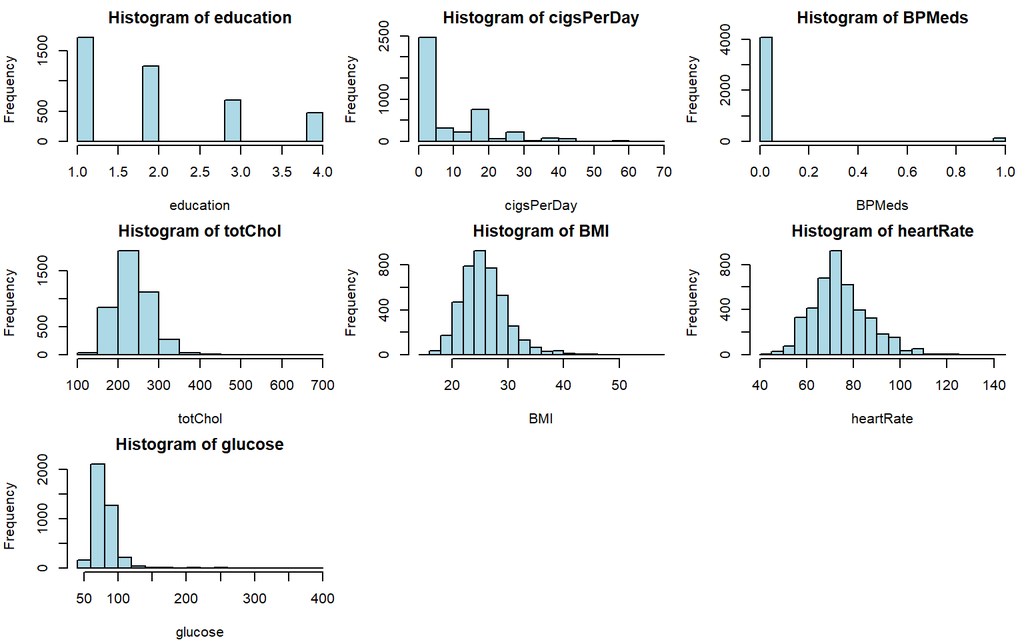

```r
par(mfrow=c(3,3), mar=c(4,4,2,0.5))
for (j in 1:ncol(df[c(3,5,6,10,13,14,15)])) {
  hist(df[c(3,5,6,10,13,14,15)][,j], xlab=colnames(df[c(3,5,6,10,13,14,15)])[j],
       main=paste("Histogram of", colnames(df[c(3,5,6,10,13,14,15)])[j]),
       col="lightblue", breaks=20)
}
```

```r
summary(df[c(3,5,6,10,13,14,15)])
```

```
##    education       cigsPerDay         BPMeds           totChol
##  Min.   :1.000   Min.   : 0.000   Min.   :0.00000   Min.   :107.0
##  1st Qu.:1.000   1st Qu.: 0.000   1st Qu.:0.00000   1st Qu.:206.0
##  Median :2.000   Median : 0.000   Median :0.00000   Median :234.0
##  Mean   :1.979   Mean   : 9.003   Mean   :0.02963   Mean   :236.7
##  3rd Qu.:3.000   3rd Qu.:20.000   3rd Qu.:0.00000   3rd Qu.:263.0
##  Max.   :4.000   Max.   :70.000   Max.   :1.00000   Max.   :696.0
##  NA's   :105     NA's   :29       NA's   :53        NA's   :50
##       BMI          heartRate         glucose
##  Min.   :15.54   Min.   : 44.00   Min.   : 40.00
##  1st Qu.:23.07   1st Qu.: 68.00   1st Qu.: 71.00
##  Median :25.40   Median : 75.00   Median : 78.00
##  Mean   :25.80   Mean   : 75.88   Mean   : 81.97
##  3rd Qu.:28.04   3rd Qu.: 83.00   3rd Qu.: 87.00
##  Max.   :56.80   Max.   :143.00   Max.   :394.00
##  NA's   :19      NA's   :1        NA's   :388
```

Nello specifico, si è scelto di imputare con i valori NA con i valori più frequenti di cianscuna distribuzione:

```r
df =df %>%
      replace_na(list(education = 1, cigsPerDay = 0, BPMeds = 0, totChol = 234,
                  BMI = 25.40, heartRate = 75, glucose = 78))
```

## Factor Trasformation

Il secondo aspetto di cui ci si è occupato è la conversione della variabili di tipo categorico in variabili di tipo fattore attraverso la funzione `factor()`:

```r
df$male <- factor(df$male)
df$education <- factor(df$education)
df$currentSmoker <- factor(df$currentSmoker)
df$BPMeds <- factor(df$BPMeds)
df$prevalentStroke <- factor(df$prevalentStroke)
df$prevalentHyp <- factor(df$prevalentHyp)
df$diabetes <- factor(df$diabetes)
df$TenYearCHD <- factor(df$TenYearCHD)
df$education <- factor(df$education)
```

Possiamo ora osservare gli effetti delle trasformazioni appena effettuate:

```r
str(df)
```

```
## 'data.frame':    4238 obs. of  16 variables:
##  $ male           : Factor w/ 2 levels "0","1": 2 1 2 1 1 1 1 1 2 2 ...
##  $ age            : int  39 46 48 61 46 43 63 45 52 43 ...
##  $ education      : Factor w/ 4 levels "1","2","3","4": 4 2 1 3 3 2 1 2 1 1 ...
##  $ currentSmoker  : Factor w/ 2 levels "0","1": 1 1 2 2 2 1 1 2 1 2 ...
##  $ cigsPerDay     : num  0 0 20 30 23 0 0 20 0 30 ...
##  $ BPMeds         : Factor w/ 2 levels "0","1": 1 1 1 1 1 1 1 1 1 1 ...
##  $ prevalentStroke: Factor w/ 2 levels "0","1": 1 1 1 1 1 1 1 1 1 1 ...
##  $ prevalentHyp   : Factor w/ 2 levels "0","1": 1 1 1 2 1 2 1 1 2 2 ...
##  $ diabetes       : Factor w/ 2 levels "0","1": 1 1 1 1 1 1 1 1 1 1 ...
##  $ totChol        : num  195 250 245 225 285 228 205 313 260 225 ...
##  $ sysBP          : num  106 121 128 150 130 ...
##  $ diaBP          : num  70 81 80 95 84 110 71 71 89 107 ...
##  $ BMI            : num  27 28.7 25.3 28.6 23.1 ...
##  $ heartRate      : num  80 95 75 65 85 77 60 79 76 93 ...
##  $ glucose        : num  77 76 70 103 85 99 85 78 79 88 ...
##  $ TenYearCHD     : Factor w/ 2 levels "0","1": 1 1 1 2 1 1 2 1 1 1 ...
```

```r
skim(df)
```

Data summary

| Name | df |
| --- | --- |
| Number of rows | 4238 |
| Number of columns | 16 |
| _______________________ |  |
| Column type frequency: |  |
| factor | 8 |
| numeric | 8 |
| ________________________ |  |
| Group variables | None |

**Variable type: factor**

| skim_variable | n_missing | complete_rate | ordered | n_unique | top_counts |
| --- | --- | --- | --- | --- | --- |
| male | 0 | 1 | FALSE | 2 | 0: 2419, 1: 1819 |
| education | 0 | 1 | FALSE | 4 | 1: 1825, 2: 1253, 3: 687, 4: 473 |
| currentSmoker | 0 | 1 | FALSE | 2 | 0: 2144, 1: 2094 |
| BPMeds | 0 | 1 | FALSE | 2 | 0: 4114, 1: 124 |
| prevalentStroke | 0 | 1 | FALSE | 2 | 0: 4213, 1: 25 |
| prevalentHyp | 0 | 1 | FALSE | 2 | 0: 2922, 1: 1316 |
| diabetes | 0 | 1 | FALSE | 2 | 0: 4129, 1: 109 |
| TenYearCHD | 0 | 1 | FALSE | 2 | 0: 3594, 1: 644 |

**Variable type: numeric**

| skim_variable | n_missing | complete_rate | mean | sd | p0 | p25 | p50 | p75 | p100 | hist |
| --- | --- | --- | --- | --- | --- | --- | --- | --- | --- | --- |
| age | 0 | 1 | 49.58 | 8.57 | 32.00 | 42.00 | 49.0 | 56.00 | 70.0 | ▃▇▆▆▂ |
| cigsPerDay | 0 | 1 | 8.94 | 11.90 | 0.00 | 0.00 | 0.0 | 20.00 | 70.0 | ▇▃▁▁▁ |
| totChol | 0 | 1 | 236.69 | 44.33 | 107.00 | 206.00 | 234.0 | 262.00 | 696.0 | ▆▇▁▁▁ |
| sysBP | 0 | 1 | 132.35 | 22.04 | 83.50 | 117.00 | 128.0 | 144.00 | 295.0 | ▇▇▁▁▁ |
| diaBP | 0 | 1 | 82.89 | 11.91 | 48.00 | 75.00 | 82.0 | 89.88 | 142.5 | ▁▇▅▁▁ |
| BMI | 0 | 1 | 25.80 | 4.07 | 15.54 | 23.08 | 25.4 | 28.04 | 56.8 | ▅▇▁▁▁ |
| heartRate | 0 | 1 | 75.88 | 12.03 | 44.00 | 68.00 | 75.0 | 83.00 | 143.0 | ▂▇▃▁▁ |
| glucose | 0 | 1 | 81.60 | 22.87 | 40.00 | 72.00 | 78.0 | 85.00 | 394.0 | ▇▁▁▁▁ |

Le variabili di tipo categorico sono state convertite tutte correttamente e l’imputazione dei valori mancanti è andata a buon fine.

## Response Variable

Si propone di seguito uno studio dettagliato riguardo la variabile dipendente `tenYearCHD`: tramite l’ausilio di alcuni boxplot si è cercato di mettere in risalto le possibili relazini che intercorrono tra la variabile ogetto di studio ed alcune delle variabili indipendenti presenti nel Data Set:

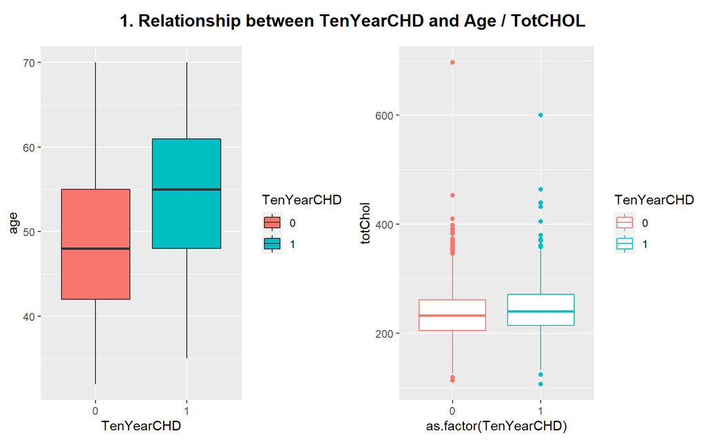

```r
x <- ggplot(data = df, mapping = aes(x = TenYearCHD, y = age, fill = TenYearCHD)) +
  geom_boxplot()
y <- ggplot(data = df, mapping = aes(x = as.factor(TenYearCHD), y = totChol, color = TenYearCHD)) +
  geom_boxplot()
p <- cowplot::plot_grid(x, y)
title <- cowplot::ggdraw() + cowplot::draw_label("1. Relationship between TenYearCHD and Age / TotCHOL", fontface='bold')
cowplot::plot_grid(title, p, ncol=1, rel_heights=c(0.1, 1))
```

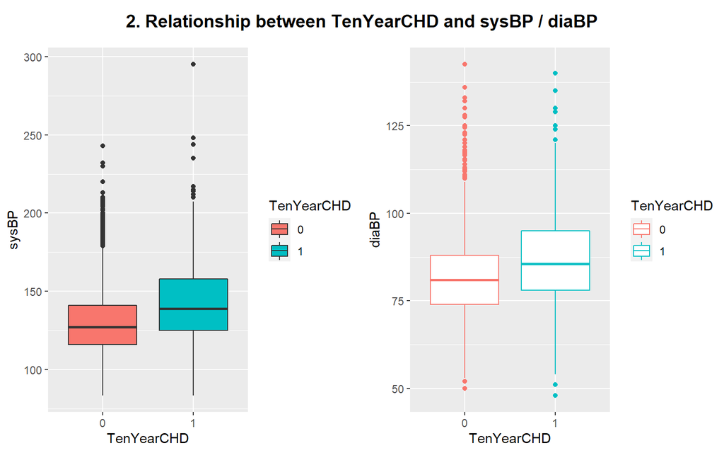

```r
x <- ggplot(data = df, mapping = aes(x = TenYearCHD, y = sysBP, fill = TenYearCHD)) +
  geom_boxplot()
y <- ggplot(data = df, mapping = aes(x = TenYearCHD, y = diaBP, color = TenYearCHD)) +
  geom_boxplot()
p <- plot_grid(x, y)
title <- ggdraw() + draw_label("2. Relationship between TenYearCHD and sysBP / diaBP", fontface='bold')
plot_grid(title, p, ncol=1, rel_heights=c(0.1, 1))
```

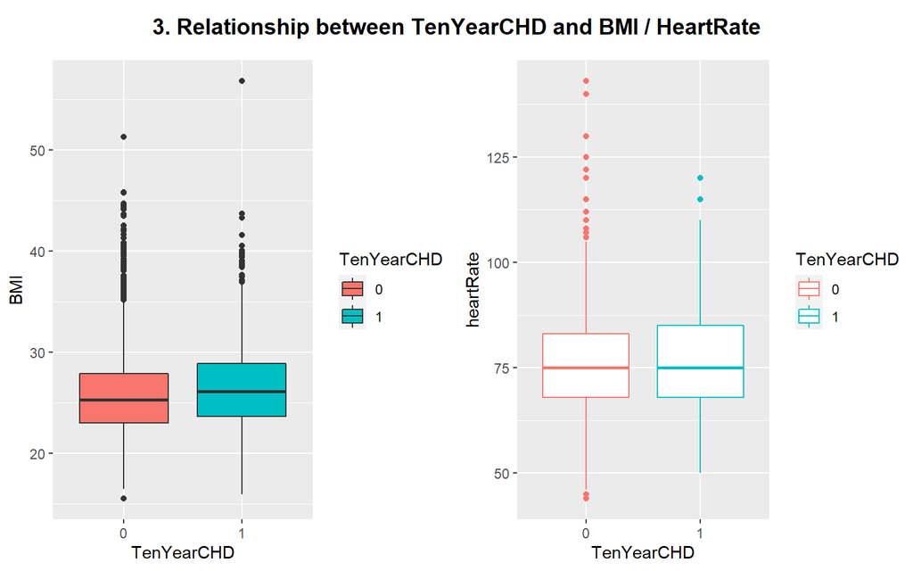

```r
x <- ggplot(data = df, mapping = aes(x = TenYearCHD, y = BMI, fill = TenYearCHD)) +
  geom_boxplot()
y <- ggplot(data = df, mapping = aes(x = TenYearCHD, y = heartRate, color = TenYearCHD)) +
  geom_boxplot()
p <- plot_grid(x, y)
title <- ggdraw() + draw_label("3. Relationship between TenYearCHD and BMI / HeartRate", fontface='bold')
plot_grid(title, p, ncol=1, rel_heights=c(0.1, 1))
```

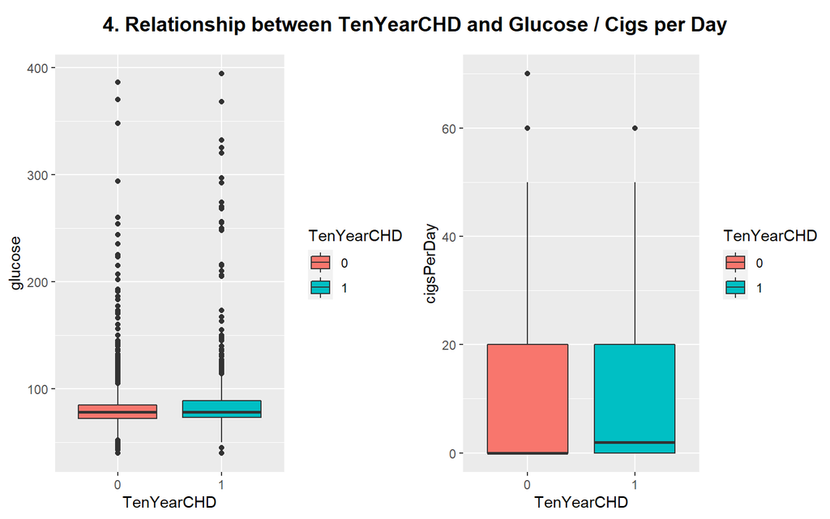

```r
x <- ggplot(data = df, mapping = aes(x = TenYearCHD, y = glucose, fill = TenYearCHD)) +
  geom_boxplot()
y <- ggplot(data = df, mapping = aes(x = TenYearCHD, y = cigsPerDay, fill = TenYearCHD)) +
  geom_boxplot()
p <- plot_grid(x,y)
title <- ggdraw() + draw_label("4. Relationship between TenYearCHD and Glucose / Cigs per Day", fontface='bold')
plot_grid(title, p, ncol=1, rel_heights=c(0.1, 1))
```

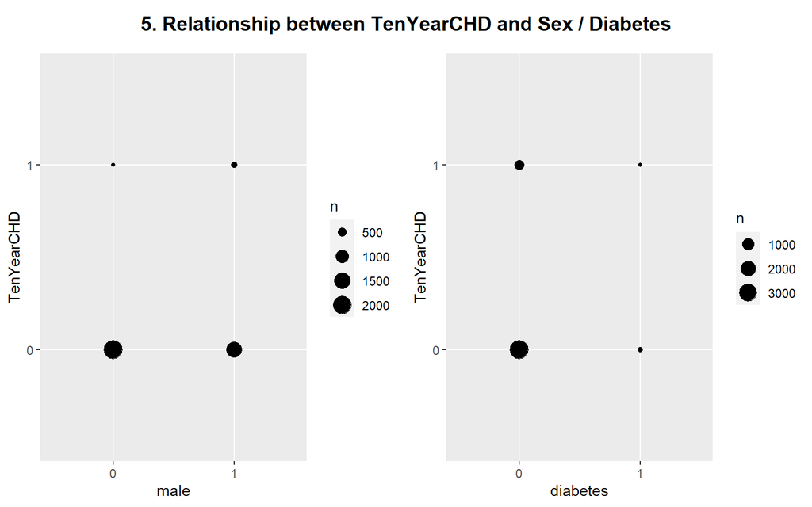

```r
x <- ggplot(data = df) +
  geom_count(mapping = aes(x = male, y = TenYearCHD))
y <- ggplot(data = df) +
  geom_count(mapping = aes(x = diabetes, y = TenYearCHD))
p <- plot_grid(x, y)
title <- ggdraw() + draw_label("5. Relationship between TenYearCHD and Sex / Diabetes", fontface='bold')
plot_grid(title, p, ncol=1, rel_heights=c(0.1, 1))
```

Da tali plot possiamo apprendere che:

- i pazienti con CHD (Coronary Heart Disease) hanno età media e livelli di colesterlono più elevati;
- i pazienti con CHD hanno livelli più alti di pressione sistolica e diastolica;
- i pazienti con CHD hanno un indice di massa corporeo più elevato, ma un battito cardiaco medio uguale ai soggetti che non hanno la CHD;
- i pazienti con e senza CHD hanno livelli di glucosio simili;
- sono più i pazienti maschi che le pazienti donne ad avere la CHD, e sono più i non diabetici ad avere la CHD

## Correlations

Possiamo osservare la struttura di correlazione tra le variabili che compongono il nostro Data Set plottando la matrice di correlazione. Essendoci alcune variabili categoriche possiamo calcolare la correlazione tra loro costruendo la matrice di correlazione a partire dalla funzione `model.matrix()`; tale funzione fa il One Hot Encoding della variabili categoriche e calcola la correlazione esattamente come farebbe un classico modello di regressione trattando i livelli della variabile categorica come variabili distinte.

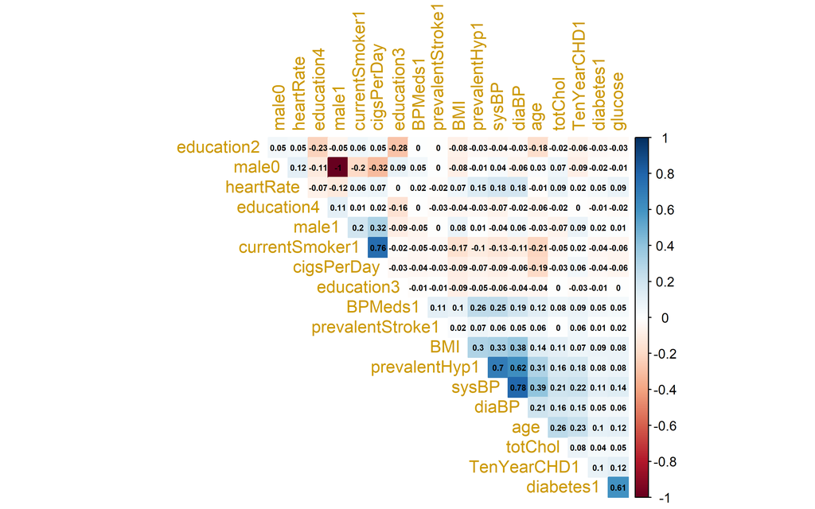

```r
model.matrix(~0+., data = df) %>%
  cor(use="pairwise.complete.obs") %>%
  corrplot(method = "color", type = "upper",number.cex = .5, order="hclust", addCoef.col = "black",tl.col = "#CC9900",            diag=F)
```

## Train-test Split

Si è diviso successivamente il Data Set in Training Set e Test Set optando per una proporzione rispettivamente dell’80 e del 20%.

```r
set.seed(123)
split = createDataPartition(y = df$TenYearCHD, p= 0.8, list = F)
x_train = df[split,]
x_test = df[-split,]
```

```r
dim(x_train)
```

```
## [1] 3392   16
```

```r
dim(x_test)
```

```
## [1] 846  16
```

## Oversampling for imbalanced classes

Si è notato, successivamente un certo sbilanciamento tra le due classi appartenenti alla variabile ogetto di studio. Nello specifico la classe negativa e di gran lunga maggiore rispetto alla classe positiva. Questo farà si che i nostri modelli risultino “high specificity” nel senso che la classe negativa verrà prevista molto più accuratamente rispetto alla classe positiva (che è la classe che ci interessa maggiormente prevedere):

```r
table(x_train$TenYearCHD)
```

```
##
##    0    1
## 2876  516
```

Per ovviare a tale problema possiamo aumentare la sensitività svolgendo l’Oversampling della classe in minoranza tramite la funzione `ovun.sample()`: tale funzione permette di ricampionare casualmente alcune delle osservazioni appartenenti alla classe in minoranza allo scopo di bilanciare il più possibile le due classi. Attraverso questa tecnica, al costo di una diminuizione rispetto al livello di accuratezza del modello, ci permette di prevedere in maniera più accurata la classe positiva

```r
x_train = ovun.sample(TenYearCHD ~., data= x_train, method = "over", seed = 123)$data
```

```r
table(x_train$TenYearCHD)
```

```
##
##    0    1
## 2876 2847
```

Come possiamo osservare la classe positiva (quella in minoranza) è passata da 516 osservazioni a 2847 arrivando quasi a bilanciare perfettamente la classe negativa (2876 osservazioni). Il Data Set è pronto ora per l’analisi di classificazione.

# Classifier Comparison

```r
control <- trainControl(method="repeatedcv", number=10, repeats=3)
```

## Logistic Regression

```r
set.seed(123)
glm_clf <- train(TenYearCHD ~., data = x_train,
                         method = "glm",
                         tuneLength = 10,
                         trControl = control,
                 )
glm_clf
```

```
## Generalized Linear Model
##
## 5723 samples
##   15 predictor
##    2 classes: '0', '1'
##
## No pre-processing
## Resampling: Cross-Validated (10 fold, repeated 3 times)
## Summary of sample sizes: 5151, 5150, 5151, 5152, 5150, 5152, ...
## Resampling results:
##
##   Accuracy   Kappa
##   0.6698039  0.3396413
```

## LDA - Linear Discriminant Analysis

```r
set.seed(123)
lda_clf = train(TenYearCHD ~., data = x_train, method="lda", trControl=control)
lda_clf
```

```
## Linear Discriminant Analysis
##
## 5723 samples
##   15 predictor
##    2 classes: '0', '1'
##
## No pre-processing
## Resampling: Cross-Validated (10 fold, repeated 3 times)
## Summary of sample sizes: 5151, 5150, 5151, 5152, 5150, 5152, ...
## Resampling results:
##
##   Accuracy   Kappa
##   0.6738218  0.3477009
```

## SVM - Support Vector Machine

```r
set.seed(7)
svm_clf = train(TenYearCHD ~., data = x_train, method = "svmLinear", trControl = control)

svm_clf
```

```
## Support Vector Machines with Linear Kernel
##
## 5723 samples
##   15 predictor
##    2 classes: '0', '1'
##
## No pre-processing
## Resampling: Cross-Validated (10 fold, repeated 3 times)
## Summary of sample sizes: 5151, 5150, 5150, 5151, 5150, 5151, ...
## Resampling results:
##
##   Accuracy   Kappa
##   0.6707476  0.3416666
##
## Tuning parameter 'C' was held constant at a value of 1
```

## Random Forest

```r
set.seed(123)
forest_clf = train(TenYearCHD ~., data = x_train, method = "rf",
                   trControl = control)

forest_clf
```

```
## Random Forest
##
## 5723 samples
##   15 predictor
##    2 classes: '0', '1'
##
## No pre-processing
## Resampling: Cross-Validated (10 fold, repeated 3 times)
## Summary of sample sizes: 5151, 5150, 5151, 5152, 5150, 5152, ...
## Resampling results across tuning parameters:
##
##   mtry  Accuracy   Kappa
##    2    0.9228818  0.8458278
##    9    0.9775744  0.9551555
##   17    0.9719245  0.9438610
##
## Accuracy was used to select the optimal model using the largest value.
## The final value used for the model was mtry = 9.
```

## XGB - eXtreme Gradient Boosting

```r
set.seed(123)
xgb_grid_1  <-  expand.grid(
                  nrounds = 50,
                  eta = c(0.03),
                  max_depth = 1,
                  gamma = 0,
                  colsample_bytree = 0.6,
                  min_child_weight = 1,
                  subsample = 0.5
                )

xgb_clf = train(TenYearCHD ~., data = x_train,
                method = "xgbTree",
                tuneGrid=xgb_grid_1,
                trControl = control
                )

xgb_clf
```

[output not shown]

## KNN - K Nearest Neighbours

```r
set.seed(123)
knn_clf = train(TenYearCHD ~., data = x_train,
                method = "knn",
                tuneGrid = expand.grid(.k = c(3:10)),
                trControl = control,
                )

knn_clf
```

```
## k-Nearest Neighbors
##
## 5723 samples
##   15 predictor
##    2 classes: '0', '1'
##
## No pre-processing
## Resampling: Cross-Validated (10 fold, repeated 3 times)
## Summary of sample sizes: 5151, 5150, 5151, 5152, 5150, 5152, ...
## Resampling results across tuning parameters:
##
##   k   Accuracy   Kappa
##    3  0.8215971  0.6437393
##    4  0.7808849  0.5625261
##    5  0.7543847  0.5096826
##    6  0.7300400  0.4610397
##    7  0.7215958  0.4441412
##    8  0.7111681  0.4232453
##    9  0.7035982  0.4080353
##   10  0.7066828  0.4141033
##
## Accuracy was used to select the optimal model using the largest value.
## The final value used for the model was k = 3.
```

## Model Evaluation

Possiamo ora mostrare i risultati ottenuti sul Training Set nella fase di “fitting” dei modelli allo scopo di fornire un confronto tra essi:

```r
results = resamples(list(LOGREG=glm_clf, LDA=lda_clf, SVM=svm_clf, KNN=knn_clf, RF=forest_clf, XGB = xgb_clf))
```

```r
summary(results)
```

```
##
## Call:
## summary.resamples(object = results)
##
## Models: LOGREG, LDA, SVM, KNN, RF, XGB
## Number of resamples: 30
##
## Accuracy
##             Min.   1st Qu.    Median      Mean   3rd Qu.      Max. NA's
## LOGREG 0.6322242 0.6582168 0.6736475 0.6698039 0.6804887 0.7085515    0
## LDA    0.6322242 0.6652098 0.6768556 0.6738218 0.6845794 0.7137871    0
## SVM    0.6404887 0.6595280 0.6716155 0.6707476 0.6765734 0.7080420    0
## KNN    0.7919580 0.8130187 0.8219895 0.8215971 0.8250983 0.8479021    0
## RF     0.9702277 0.9725016 0.9781483 0.9775744 0.9807944 0.9860384    0
## XGB    0.5996503 0.6323849 0.6401744 0.6418480 0.6538622 0.7120419    0
##
## Kappa
##             Min.   1st Qu.    Median      Mean   3rd Qu.      Max. NA's
## LOGREG 0.2647798 0.3164916 0.3473009 0.3396413 0.3611266 0.4171402    0
## LDA    0.2648069 0.3304174 0.3538502 0.3477009 0.3691313 0.4276003    0
## SVM    0.2812203 0.3192080 0.3434225 0.3416666 0.3533049 0.4162409    0
## KNN    0.5844749 0.6267478 0.6445215 0.6437393 0.6506240 0.6960643    0
## RF     0.9404723 0.9450166 0.9563023 0.9551555 0.9615937 0.9720791    0
## XGB    0.2007664 0.2655585 0.2812680 0.2844684 0.3084049 0.4244151    0
```

Si nota come a livello di performance media l’algoritmo che lavora meglio e il Random Forest con un accuracy pari a circa 0.98. Possiamo anche plottare tali risultati allo scopo di visualizzarli meglio:

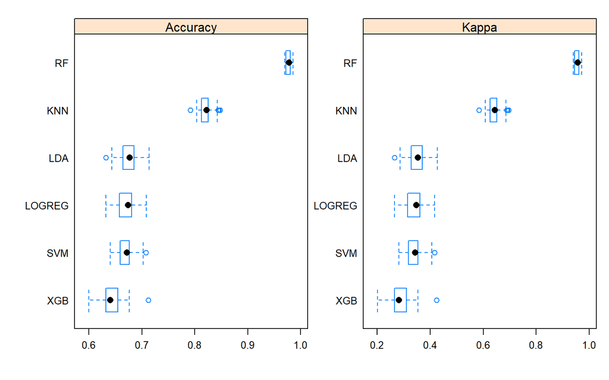

```r
scales = list(x=list(relation="free"), y=list(relation="free"))
bwplot(results, scales=scales)
```

Anche in questo caso possiamo osservare come il `RandomForest` sia l’algoritmo che ha performato meglio sul Training Set in quanto mostra il box-plot più compatto e spostato verso destra.

## Performance on Test Set

Si passa ora a mostrare i risultati di performance ottenuti sul Test Set. Nello pecifico raccogliamo le previsioni contenenti la classe predetta e degli scores calcolati come la probabilità di appartenenza ad una delle due classi. Le previsioni saranno utili per la computazione delle matrici di confusione, mentre gli scores saranno utili per il calcolo delle curve ROC e delle AUC (Area Under the Curve).

```r
glm_predictions = predict(glm_clf, x_test)
lda_predictions = predict(lda_clf, x_test)
svm_predictions = predict(svm_clf, x_test)
knn_predictions = predict(knn_clf, x_test)
forest_predictions = predict(forest_clf, x_test)
xgb_predictions = predict(xgb_clf, x_test)

glm_scores = predict(glm_clf, x_test, type = "prob")
lda_scores = predict(lda_clf, x_test, type = "prob")
knn_scores = predict(knn_clf, x_test, type = "prob")
forest_scores = predict(forest_clf, x_test, type = "prob")
xgb_scores = predict(xgb_clf, x_test, type = "prob")
```

```r
cm_glm = confusionMatrix(data = glm_predictions, reference = x_test$TenYearCHD, positive = "1")
cm_glm
```

```
## Confusion Matrix and Statistics
##
##           Reference
## Prediction   0   1
##          0 484  43
##          1 234  85
##
##                Accuracy : 0.6726
##                  95% CI : (0.6398, 0.7041)
##     No Information Rate : 0.8487
##     P-Value [Acc > NIR] : 1
##
##                   Kappa : 0.2096
##
##  Mcnemar's Test P-Value : <2e-16
##
##             Sensitivity : 0.6641
##             Specificity : 0.6741
##          Pos Pred Value : 0.2665
##          Neg Pred Value : 0.9184
##              Prevalence : 0.1513
##          Detection Rate : 0.1005
##    Detection Prevalence : 0.3771
##       Balanced Accuracy : 0.6691
##
##        'Positive' Class : 1
##
```

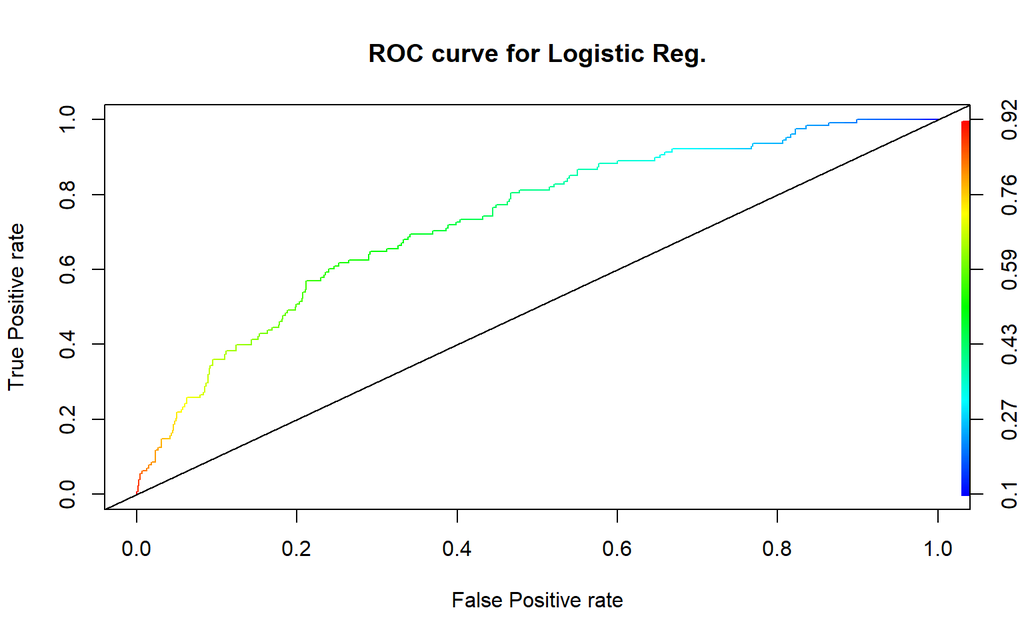

```r
pred_roc_glm = prediction(glm_scores[,2], x_test$TenYearCHD)
glm_ROCR = performance(pred_roc_glm, measure = "tpr", x.measure = "fpr")
par(mfrow=c(1,1))
plot(glm_ROCR, main = "ROC curve for Logistic Reg.", colorize = T, xlab="False Positive rate", ylab="True Positive rate" )
abline(a = 0, b = 1)
```

```r
auc_glm = performance(pred_roc_glm, measure = "auc")
auc_glm = auc_glm@y.values[[1]]
auc_glm
```

```
## [1] 0.7328408
```

```r
cm_lda = confusionMatrix(data = lda_predictions, reference = x_test$TenYearCHD, positive = "1")
cm_lda
```

```
## Confusion Matrix and Statistics
##
##           Reference
## Prediction   0   1
##          0 482  42
##          1 236  86
##
##                Accuracy : 0.6714
##                  95% CI : (0.6386, 0.703)
##     No Information Rate : 0.8487
##     P-Value [Acc > NIR] : 1
##
##                   Kappa : 0.2115
##
##  Mcnemar's Test P-Value : <2e-16
##
##             Sensitivity : 0.6719
##             Specificity : 0.6713
##          Pos Pred Value : 0.2671
##          Neg Pred Value : 0.9198
##              Prevalence : 0.1513
##          Detection Rate : 0.1017
##    Detection Prevalence : 0.3806
##       Balanced Accuracy : 0.6716
##
##        'Positive' Class : 1
##
```

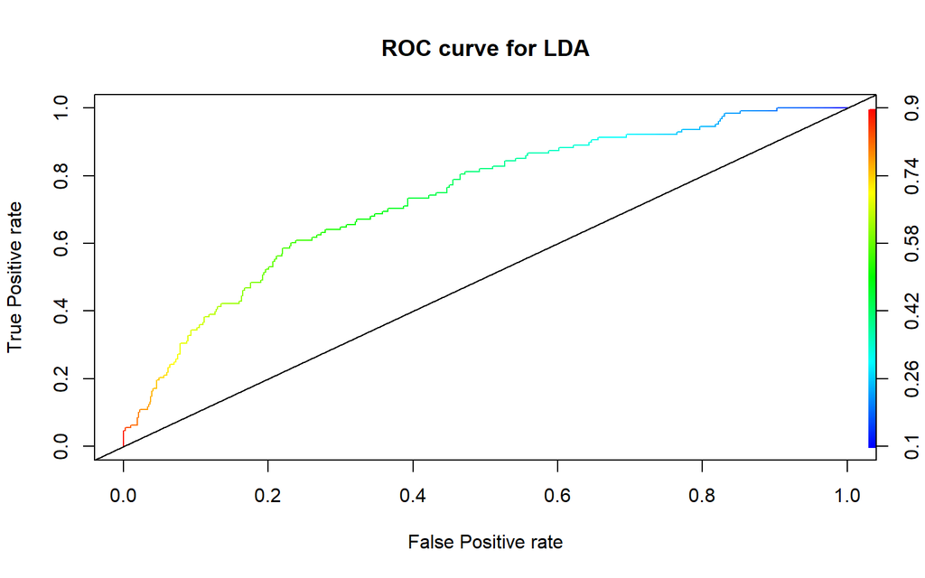

```r
pred_roc_lda = prediction(lda_scores[,2], x_test$TenYearCHD)
lda_ROCR = performance(pred_roc_lda, measure = "tpr", x.measure = "fpr")
par(mfrow=c(1,1))
plot(lda_ROCR, main = "ROC curve for LDA", colorize = T, xlab="False Positive rate", ylab="True Positive rate" )
abline(a = 0, b = 1)
```

```r
auc_lda = performance(pred_roc_lda, measure = "auc")
auc_lda = auc_lda@y.values[[1]]
auc_lda
```

```
## [1] 0.7341356
```

```r
cm_svm = confusionMatrix(data = svm_predictions, reference = x_test$TenYearCHD, positive = "1")
cm_svm
```

```
## Confusion Matrix and Statistics
##
##           Reference
## Prediction   0   1
##          0 459  42
##          1 259  86
##
##                Accuracy : 0.6442
##                  95% CI : (0.6109, 0.6765)
##     No Information Rate : 0.8487
##     P-Value [Acc > NIR] : 1
##
##                   Kappa : 0.1834
##
##  Mcnemar's Test P-Value : <2e-16
##
##             Sensitivity : 0.6719
##             Specificity : 0.6393
##          Pos Pred Value : 0.2493
##          Neg Pred Value : 0.9162
##              Prevalence : 0.1513
##          Detection Rate : 0.1017
##    Detection Prevalence : 0.4078
##       Balanced Accuracy : 0.6556
##
##        'Positive' Class : 1
##
```

```r
cm_knn = confusionMatrix(data = knn_predictions, reference = x_test$TenYearCHD, positive = "1")
cm_knn
```

```
## Confusion Matrix and Statistics
##
##           Reference
## Prediction   0   1
##          0 511  70
##          1 207  58
##
##                Accuracy : 0.6726
##                  95% CI : (0.6398, 0.7041)
##     No Information Rate : 0.8487
##     P-Value [Acc > NIR] : 1
##
##                   Kappa : 0.1145
##
##  Mcnemar's Test P-Value : 3.047e-16
##
##             Sensitivity : 0.45312
##             Specificity : 0.71170
##          Pos Pred Value : 0.21887
##          Neg Pred Value : 0.87952
##              Prevalence : 0.15130
##          Detection Rate : 0.06856
##    Detection Prevalence : 0.31324
##       Balanced Accuracy : 0.58241
##
##        'Positive' Class : 1
##
```

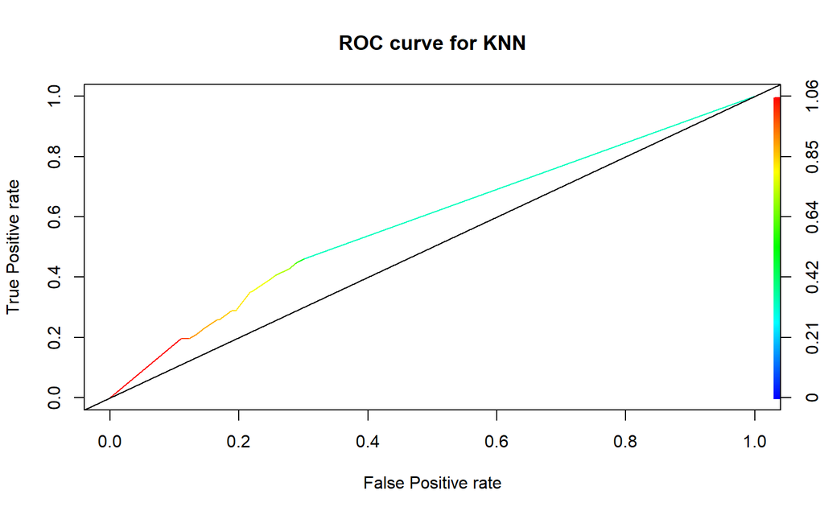

```r
pred_roc_knn = prediction(knn_scores[,2], x_test$TenYearCHD)
knn_ROCR = performance(pred_roc_knn, measure = "tpr", x.measure = "fpr")
par(mfrow=c(1,1))
plot(knn_ROCR, main = "ROC curve for KNN", colorize = T, xlab="False Positive rate", ylab="True Positive rate" )
abline(a = 0, b = 1)
```

```r
auc_knn = performance(pred_roc_knn, measure = "auc")
auc_knn = auc_knn@y.values[[1]]
auc_knn
```

```
## [1] 0.5829072
```

```r
cm_forest = confusionMatrix(data = forest_predictions, reference = x_test$TenYearCHD, positive = "1")
cm_forest
```

```
## Confusion Matrix and Statistics
##
##           Reference
## Prediction   0   1
##          0 687 115
##          1  31  13
##
##                Accuracy : 0.8274
##                  95% CI : (0.8002, 0.8523)
##     No Information Rate : 0.8487
##     P-Value [Acc > NIR] : 0.9602
##
##                   Kappa : 0.0799
##
##  Mcnemar's Test P-Value : 6.46e-12
##
##             Sensitivity : 0.10156
##             Specificity : 0.95682
##          Pos Pred Value : 0.29545
##          Neg Pred Value : 0.85661
##              Prevalence : 0.15130
##          Detection Rate : 0.01537
##    Detection Prevalence : 0.05201
##       Balanced Accuracy : 0.52919
##
##        'Positive' Class : 1
##
```

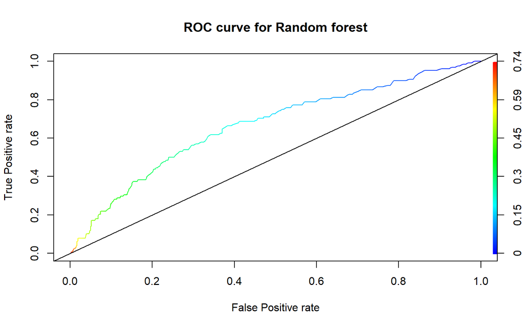

```r
pred_roc_forest = prediction(forest_scores[,2], x_test$TenYearCHD)
forest_ROCR = performance(pred_roc_forest, measure = "tpr", x.measure = "fpr")
par(mfrow=c(1,1))
plot(forest_ROCR, main = "ROC curve for Random forest", colorize = T, xlab="False Positive rate", ylab="True Positive rate" )
abline(a = 0, b = 1)
```

```r
auc_forest = performance(pred_roc_forest, measure = "auc")
auc_forest = auc_forest@y.values[[1]]
auc_forest
```

```
## [1] 0.6656783
```

```r
cm_xgb = confusionMatrix(data = xgb_predictions, reference = x_test$TenYearCHD, positive = "1")
cm_xgb
```

```
## Confusion Matrix and Statistics
##
##           Reference
## Prediction   0   1
##          0 397  37
##          1 321  91
##
##                Accuracy : 0.5768
##                  95% CI : (0.5427, 0.6104)
##     No Information Rate : 0.8487
##     P-Value [Acc > NIR] : 1
##
##                   Kappa : 0.138
##
##  Mcnemar's Test P-Value : <2e-16
##
##             Sensitivity : 0.7109
##             Specificity : 0.5529
##          Pos Pred Value : 0.2209
##          Neg Pred Value : 0.9147
##              Prevalence : 0.1513
##          Detection Rate : 0.1076
##    Detection Prevalence : 0.4870
##       Balanced Accuracy : 0.6319
##
##        'Positive' Class : 1
##
```

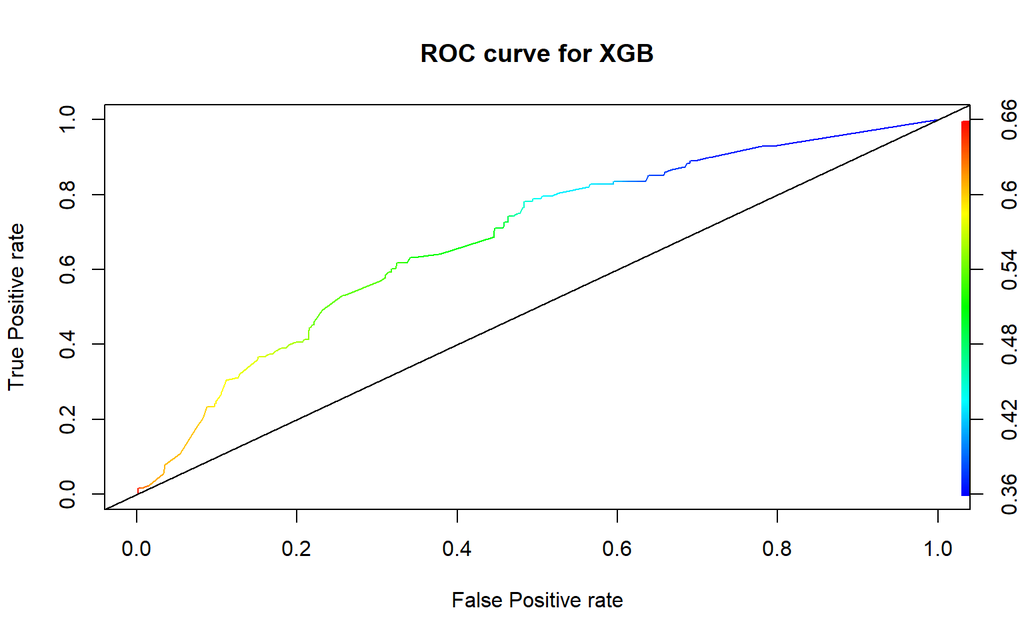

```r
pred_roc_xgb = prediction(xgb_scores[,2], x_test$TenYearCHD)
xgb_ROCR = performance(pred_roc_xgb, measure = "tpr", x.measure = "fpr")
par(mfrow=c(1,1))
plot(xgb_ROCR, main = "ROC curve for XGB", colorize = T, xlab="False Positive rate", ylab="True Positive rate" )
abline(a = 0, b = 1)
```

```r
auc_xgb = performance(pred_roc_xgb, measure = "auc")
auc_xgb = auc_xgb@y.values[[1]]
auc_xgb
```

```
## [1] 0.6823316
```

```r
ModelType = c( "LOGREG", "LDA", "SVM", "KNN", "Random forest", "XGB")
TrainAcc = c(max(glm_clf$results$Accuracy), max(lda_clf$results$Accuracy),
             max(svm_clf$results$Accuracy), max(knn_clf$results$Accuracy),
             max(forest_clf$results$Accuracy),
             max(xgb_clf$results$Accuracy))

Train_misscl_Er = 1 - TrainAcc

ValidAcc = c(cm_glm$overall[1], cm_lda$overall[1], cm_svm$overall[1],
             cm_knn$overall[1], cm_forest$overall[1],
             cm_xgb$overall[1])

Valid_misscl_Er = 1 - ValidAcc

auc_svm = NA
auc_scores = c(auc_glm, auc_lda, auc_svm, auc_knn, auc_forest, auc_xgb)

metrics = cbind(ModelType, TrainAcc, Train_misscl_Er, ValidAcc,
                      Valid_misscl_Er, auc_scores)

metrics = data.frame(metrics)

knitr::kable(metrics, digits = 3)
```

|  | ModelType | TrainAcc | Train_misscl_Er | ValidAcc | Valid_misscl_Er | auc_scores |
| --- | --- | --- | --- | --- | --- | --- |
| Accuracy | LOGREG | 0.669803885049482 | 0.330196114950518 | 0.6725768321513 | 0.3274231678487 | 0.73284079038997 |
| Accuracy.1 | LDA | 0.673821813376512 | 0.326178186623488 | 0.671394799054373 | 0.328605200945627 | 0.734135619777157 |
| Accuracy.2 | SVM | 0.670747550110017 | 0.329252449889983 | 0.644208037825059 | 0.355791962174941 | NA |
| Accuracy.3 | KNN | 0.821597119037772 | 0.178402880962228 | 0.6725768321513 | 0.3274231678487 | 0.582907163997215 |
| Accuracy.4 | Random forest | 0.977574353415855 | 0.022425646584145 | 0.8274231678487 | 0.1725768321513 | 0.665678316504178 |
| Accuracy.5 | XGB | 0.641848009475988 | 0.358151990524012 | 0.576832151300236 | 0.423167848699764 | 0.682331563370473 |

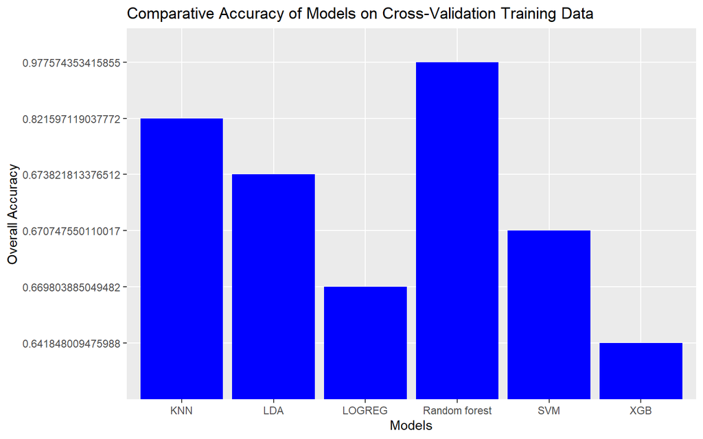

```r
model_compare = cbind(Model=ModelType, Accuracy=TrainAcc)
model_compare = data.frame(model_compare)

ggplot(aes(x=Model, y=Accuracy), data=model_compare) +
  geom_bar(stat='identity', fill = 'blue') +
  ggtitle('Comparative Accuracy of Models on Cross-Validation Training Data') +
  xlab('Models') +
  ylab('Overall Accuracy')
```

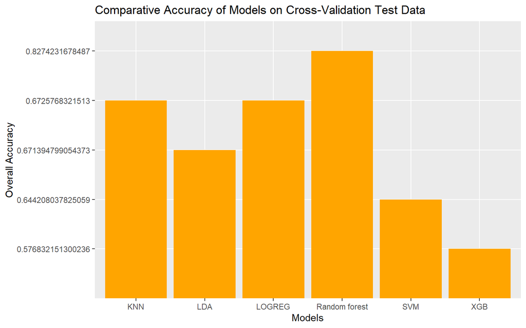

```r
model_compare = cbind(Model=ModelType, Accuracy=ValidAcc)
model_compare = data.frame(model_compare)

ggplot(aes(x=Model, y=Accuracy), data=model_compare) +
  geom_bar(stat='identity', fill = 'orange') +
  ggtitle('Comparative Accuracy of Models on Cross-Validation Test Data') +
  xlab('Models') +
  ylab('Overall Accuracy')
```

# Conclusions